# Assignment-2_data_visualisation

## lm plot

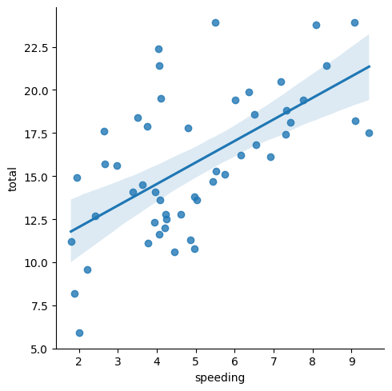

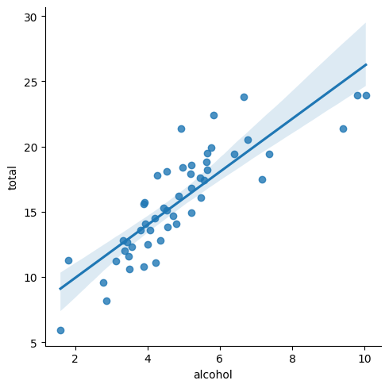

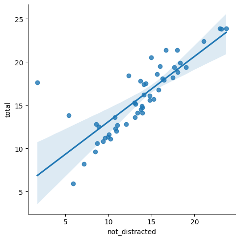

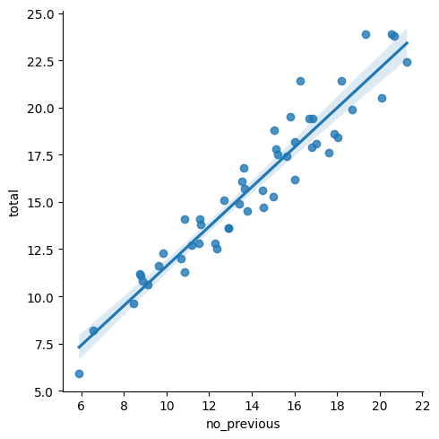

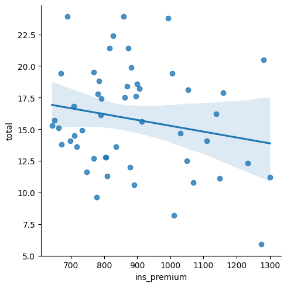

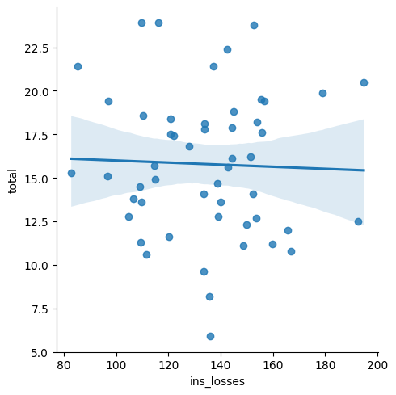

```python
for i in range(1,len(df.columns)-1):
    sns.lmplot(data=df,x=df.columns[i],y="total")
plt.show()
```

##### above lm plots showing the relation between number of drivers involved in fatal collisions per billion miles vs all other features.

##### we observe that alcohol,not_distracted,no_previous are most appropriate features in predicting the number of drivers involved in fatal collisions per billion miles from above lm plots

## Heat map

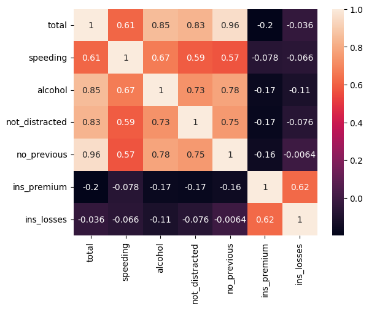

```python
sns.heatmap(df.corr(numeric_only=True),annot=True)
plt.show()
```

##### from heatmap we can observe that all features except ins premium,ins loss are highly correlated with total feature

##### we can observe that no_previous is higly positive correlated with total

##### we can also observe that no_previous is highly correlated with alcohol